# Final Project Discussion

CMSC471: Introduction to Information Visualization (Spring 2026)

The goal of this lab is to showcase your ideas, gather peer feedback, and refine your ideas. We’ve read all proposals and divided you into 6 clusters. In each cluster, you will discuss these key topics while the instructional team circulates to support every team.

See the cluster assignment below. You can find your cluster at the bottom of the Canvas page. The room is not strictly roundtable style, so settle in where designated.

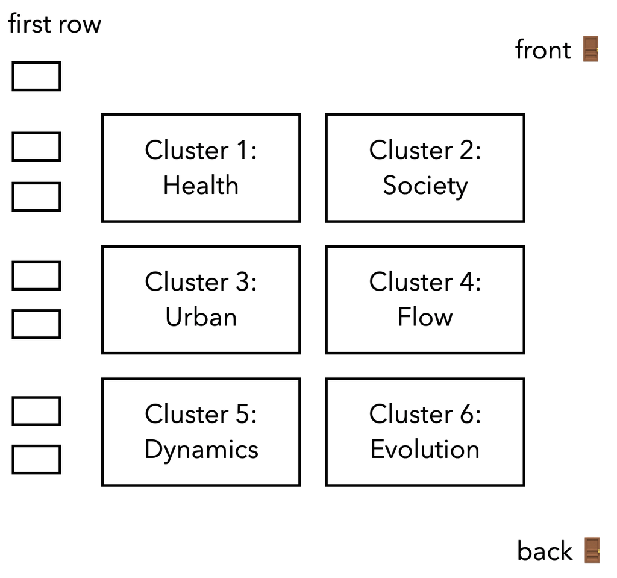

# Session Setup

Begin the session by moving to your assigned area. If more than two people from your team are present, you may split and send members to different clusters to maximize feedback coverage. Course staff will circulate to check participation, ensure every team is represented, and join discussions as needed.

Open the [peer feedback spreadsheet](https://docs.google.com/spreadsheets/d/1KKrZlRdnnvVXaOOYPRwJP8G6B0CU8d4bijVt38_sWLQ/edit?usp=sharing) (UMD email) to record feedback during discussion. While this lab is mostly graded on participation, course staff may check feedback quality during the session.

# Proposal Roundtable Discussion (within clusters; ~35 minutes)

Within each cluster, discuss team by team in speaking order (A, B, C, D).

- Round 1 (about 8 minutes): Team A presents + group discussion
- Round 2 (about 8 minutes): Team B presents + group discussion
- Round 3 (about 8 minutes): Team C presents + group discussion
- Round 4 (about 8 minutes): Team D presents + group discussion
- Buffer (about 3 minutes total): speaker transitions, notes, and timing reset

Each round should include:

## 1) Team introduction (1-3 minutes)

- An overview of the chosen dataset(s) and why they are complex enough
- The main visualization problem and the main visualization you plan to implement
- Key interaction or design ideas planned for the project
- One or two specific areas where targeted feedback is desired

## 2) Group discussion (5-8 minutes)

**Dataset selection & complexity**

- Is the dataset chosen **large**, **rich**, or **complex** enough to justify a dedicated visualization?
- Who is the **target audience**, and how is the project tailored for them?
- Is the visualization intended to be more **expressive** (insightful/story-driven) or **effective** (precise/data-driven)?

**Visual & narrative clarity**

- How clearly is the **visualization problem** defined?
- Does the current framing effectively **communicate a complex subject**?
- How could the visualization **design(s)** be improved to better serve the story or user experience?

**Interactivity & technical feasibility**

- Are interactive features meaningfully defined? Do they **enhance the narrative** or exploration?
- What are the **main technical challenges** (e.g., data cleaning, D3 complexity)? How might they be addressed?

**Team collaboration & timeline**

- Are there plans to **integrate contributions** from all team members?
- Does the team demonstrate a **realistic timeline** and division of responsibilities?

# Proposal Roundtable Discussion (across clusters; ~30 minutes)

Use this movement pattern:

- Teams in the first half (Teams A/B) stay and host
- Teams in the second half (Teams C/D) switch to a different cluster in the same row

In the new cluster, each team (or representative) gives a brief cross-cluster summary (1-3 minutes):

- A brief introduction of your project and dataset
- One strong design choice from your current proposal
- One unresolved challenge where you want targeted feedback
- One specific interaction or visual choice you are still deciding

Then discuss each team for about 3-4 minutes:

- Offer one concrete improvement suggestion
- Point out one technical risk and a practical mitigation

Discuss within your team at the end and record at least one actionable takeaway.

# Checklist

For each team, make sure you have at least one entry in the feedback document so we know you are here. Your entries should include:

- one strength for another team
- one concrete suggestion for another team